# Lab Six: CNNs

### By Xiangying Chang, Rui Lin, Fang Qi, Shimeng Yuan

# 1. Preparation

Nowadays,estimated by the SIPP(The Survey of Income and Program Participation),1 in 20 Americans are currently deaf or hard of hearing.As the hearing problems are more popular in our life,the communication between deaf sign language users and spoken language users is becoming harder.The sign language translater will be in high demand in the future. We choose the dataset for alphabets in American Sign Language, so that we could use CNN to better recognize and classify each one to provide better analysis.

The training dataset contains 87000 training images of English alphabets,which belongs to 29 categories.There are 3000 images of each category.The testing dataset has one image from each of the characters listed above.The size of each image is about 200x200 pixels.

Data source: https://www.kaggle.com/grassknoted/asl-alphabet

## 1.1 Choose metric

There are four common evaluation metrics: Accuracy, Precision, Recall, F1-score. In order to choose the appropriate metric, we need to compare these different metrics based on our data. Use letter A as example, we want to get the letter A after recognizing the gesture image which actually represents letter A, it is the best result we want, we can use True Positive to describe this condition. If we use gesture image which actually represents letter B, but the prediction result is letter A, this condition is False Positive. If we use gesture image which actually represents letter A, but the prediction result is letter B, this condition is False Negative. And the last condition is True negative which means we use gesture image which actually represents letter B and we get the result the letter is not A. The reason why we mention these four conditions is they are related to four common evaluation metrics. Accuracy indicates how many proportions of our sample are correct, this includes both TP and TN, however we want to focus on TP because it is what we would like to use in practical application. We hope people can recognize letter A from gesture image A instead of knowing the gesture image is not A and the letter is also not A. Next, considering Precision, Recall and F1-score together. Precision reflects the ability to identify negative sample, Recall reflects the ability to identify positive sample, they are both focus on TP, F1-score is the combination of these two metrics and it find a balance between Precision and Recall, so F1-score is better for our data. And for our business circumstances, most people can't recognize the sign language which corresponding to our data is that we need to improve actual large negatives to become positives, F1-score is also good for this uneven condition. Therefore, we decide to select F1-score as our metric.

There are two ways to calculate the average in F1-score: macro and micro. Macro is to calculate the TP in each category, based on our data, we can get total 2*29 values of both percision and recall, we calculate the average of each 29 values for precision and recall, then apply them to f1 formula. Micro is to combine TP for 29 categories together, get one value for precision and recall, then apply them to f1 formula. If data of each category is unbalanced, micro is preferred. However, in our data, each category has 3000 images which means distribution is balanced, so we can use macro method.

Reference:  
1.https://towardsdatascience.com/accuracy-precision-recall-or-f1-331fb37c5cb9  
2.http://sofasofa.io/forum_main_post.php?postid=1001112

## 1.2 Choose cross validation method

We are considering Stratified K-fold and stratified Shuffle splits as cross validation methods for our model. They are both shuffle the data and split the data into n_splits parts. However, there are some differences between them. For Stratified K-fold, every sample is in one fold and it only shuffles data one time before splitting. And training proportion in each iteration is k-1/k. For stratified Shuffle splits, it randomly shuffles each time before splitting and splits n_splits time, so test sets can overlap, but it is also possible that some samples are neither in the training set nor the testing set. The training proportion in each iteration is based on train_size. In our data, we want to test the accuracy of identify gesture image as right letter. Since in stratified Shuffle splits, data can be shuffled each time before splitting, it will increase the diversity and complexity of data which meets our requirements in actual life because when gesture images translater can be implemented in the future, the data collected should be diverse so that the accuracy of identify correctly is high, even though gesture images are complex, and it will increase the business application value. So we would like to use stratified Shuffle splits as our cross validation method.

Reference:  
1.https://stats.stackexchange.com/questions/270620/what-is-the-benefit-of-only-performing-a-random-split-once-at-the-beginning-duri 2.https://stackoverflow.com/questions/45969390/difference-between-stratifiedkfold-and-stratifiedshufflesplit-in-sklearn

## 1.3 upload data

```python
import keras
from keras.models import Sequential
from keras.layers import Reshape
from keras.layers import Dense, Dropout, Activation, Flatten
from keras.layers import Conv2D, MaxPooling2D
from keras.preprocessing.image import ImageDataGenerator
from keras.callbacks import EarlyStopping
from keras.regularizers import l2
from keras.layers import average
from keras.models import Input, Model
from sklearn import metrics as mt
import seaborn as sns
from sklearn.model_selection import StratifiedKFold
from sklearn.metrics import f1_score
from sklearn.model_selection import StratifiedShuffleSplit
from keras.layers.normalization import BatchNormalization
```

```python
from PIL import Image
import numpy as np
import glob
from matplotlib import pyplot as plt
%matplotlib inline


# Resize and recolor
def img_process(imageFile):
    img = Image.open(imageFile)
    img_gray = img.convert('L') # Convert RGB into grayscale

    new_img = img.resize((64, 64))
    return new_img


label_name = ['A','B','C','D','E','F','G',
              'H','I','J','K','L','M','N',
              'O','P','Q','R','S','T','U',
              'V','W','X','Y','Z','del', 'nothing', 'space'] # A-Z, del, nothing, space

images1 = []
for i in label_name:
    imageFiles1 = []
    for j in range(1,601):
        img = img_process('./asl-alphabet/asl_alphabet_train/' + i + "/" + i + str(j*5) + ".jpg")
        img = np.array(img) # Convert PIL format into numpy format
        imageFiles1.append(img)
    images1.append(imageFiles1)
```

# 2. Modeling

## 2.1 Create a Convolutional Neural Network

### 2.1.1 Data Expansion

Since we have a large dataset, so we decide to randomly select samples as our dataset for this lab. After selection, the data set has 17400 samples.

In order to creat CNN model, we need to use data expansion in Keras. We get the idea for data expansion from 11. Convolutional Neural Networks.ipynb and 12. More Advanced CNN Techniques.ipynb which provided in class. First, We decide to convert the data to the appropriate type and np.array format, then we need to reshape the data to the dimension which we need to use in CNN. And for y which represents label, we use keras.utils.to_categorical to do one more expansion. After getting y, we first use stratified Shuffle splits to get y_train and y_test, then do keras.utils.to_categorical to get y_train_ohe,y_test_ohe so that we can implement them in cnn models.

The data expansion process is appropriate for our data because the accuracy we get is good whcih can reach 0.99 in final CNNs, we have tried other data expansion techniques, however, the accuracy is around 0.4, even only 0.06 in first simple CNN, so we think the data expansion technique we use is appropriate.

Reference:  
1.https://github.com/eclarson/MachineLearningNotebooks/blob/master/11.%20Convolutional%20Neural%20Networks.ipynb  
2.https://github.com/eclarson/MachineLearningNotebooks/blob/master/12.%20More%20Advanced%20CNN%20Techniques.ipynb

```python
X = []
img_wh = 64
for i in range(len(images1)):
    for img in images1[i]:
        img = img.astype(np.float32)/16.0-0.5 # Convert uint8 into float
        X.append(img.flatten())
X = np.array(X)
X.shape
```

```
(17400, 12288)
```

```python
X = X.reshape((-1,img_wh,img_wh,3))
X.shape
```

```
(17400, 64, 64, 3)
```

```python
labels = 0
y = []
for i in range(len(images1)):
    for img in images1[i]:
        y.append(i)
    i = i+1
y =np.array(y)
y.shape
```

```
(17400,)
```

```python
NUM_CLASSES = 29
```

```python
classes = ['A','B','C','D','E','F','G',
           'H','I','J','K','L','M','N',
           'O','P','Q','R','S','T','U',
           'V','W','X','Y','Z','del', 'nothing', 'space']

datagen = ImageDataGenerator(featurewise_center=False,
    samplewise_center=False,
    featurewise_std_normalization=False,
    samplewise_std_normalization=False,
    zca_whitening=False,
    rotation_range=5, # used, Int. Degree range for random rotations.
    width_shift_range=0.1, # used, Float (fraction of total width). Range for random horizontal shifts.
    height_shift_range=0.1, # used,  Float (fraction of total height). Range for random vertical shifts.
    shear_range=0., # Float. Shear Intensity (Shear angle in counter-clockwise direction as radians)
    zoom_range=0.,
    channel_shift_range=0.,
    fill_mode='nearest',
    cval=0.,
    horizontal_flip=True,
    vertical_flip=False,
    rescale=None)
```

### We select f1_score as the evaluation metric, since Precision, Recall and F1 metrics have been removed from metrics.py, so we try to calculate f1_score by using code. The code we used in the following cell are all from reference https://stackoverflow.com/questions/43547402/how-to-calculate-f1-macro-in-keras

```python
# The code we used in the following cell are all from reference https://stackoverflow.com/questions/43547402/how-to-calculate-f1-macro-in-keras
from keras import backend as K

def f1score(y_true, y_pred):
    def recall(y_true, y_pred):
        true_positives = K.sum(K.round(K.clip(y_true * y_pred, 0, 1)))
        possible_positives = K.sum(K.round(K.clip(y_true, 0, 1)))
        recall = true_positives / (possible_positives + K.epsilon())
        return recall

    def precision(y_true, y_pred):
        true_positives = K.sum(K.round(K.clip(y_true * y_pred, 0, 1)))
        predicted_positives = K.sum(K.round(K.clip(y_pred, 0, 1)))
        precision = true_positives / (predicted_positives + K.epsilon())
        return precision
    precision = precision(y_true, y_pred)
    recall = recall(y_true, y_pred)
    return 2*((precision*recall)/(precision+recall+K.epsilon()))
```

### 2.1.2 CNN with an AlexNet style convolutional phase

Firstly, we decide to creat a simple CNN which start with an AlexNet style convolutional phase

```
WARNING:tensorflow:From /opt/conda/lib/python3.6/site-packages/tensorflow/python/framework/op_def_library.py:263: colocate_with (from tensorflow.python.framework.ops) is deprecated and will be removed in a future version.
Instructions for updating:
Colocations handled automatically by placer.
WARNING:tensorflow:From /opt/conda/lib/python3.6/site-packages/keras/backend/tensorflow_backend.py:3445: calling dropout (from tensorflow.python.ops.nn_ops) with keep_prob is deprecated and will be removed in a future version.
Instructions for updating:
Please use `rate` instead of `keep_prob`. Rate should be set to `rate = 1 - keep_prob`.
_________________________________________________________________
Layer (type)                 Output Shape              Param #
=================================================================
conv2d_1 (Conv2D)            (None, 64, 64, 32)        896
_________________________________________________________________
conv2d_2 (Conv2D)            (None, 64, 64, 64)        18496
_________________________________________________________________
max_pooling2d_1 (MaxPooling2 (None, 32, 32, 64)        0
_________________________________________________________________
dropout_1 (Dropout)          (None, 32, 32, 64)        0
_________________________________________________________________
flatten_1 (Flatten)          (None, 65536)             0
_________________________________________________________________
dense_1 (Dense)              (None, 128)               8388736
_________________________________________________________________
dropout_2 (Dropout)          (None, 128)               0
_________________________________________________________________
dense_2 (Dense)              (None, 29)                3741
=================================================================
Total params: 8,411,869
Trainable params: 8,411,869
Non-trainable params: 0
_________________________________________________________________
None
WARNING:tensorflow:From /opt/conda/lib/python3.6/site-packages/tensorflow/python/ops/math_ops.py:3066: to_int32 (from tensorflow.python.ops.math_ops) is deprecated and will be removed in a future version.
Instructions for updating:
Use tf.cast instead.
CPU times: user 6min 33s, sys: 47 s, total: 7min 20s
Wall time: 5min 34s
```

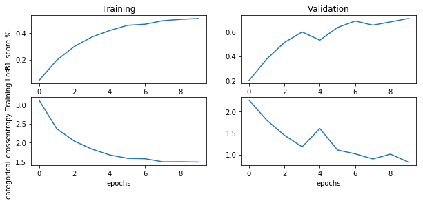

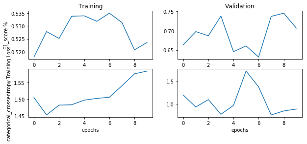

```python
%%time


cnn = Sequential()

# let's start with an AlexNet style convolutional phase
cnn.add(Conv2D(filters=32,
                input_shape = (img_wh,img_wh,3),
                kernel_size=(3,3),
                padding='same',
                activation='relu', data_format="channels_last")) # more compact syntax

# no max pool before next conv layer!!
cnn.add(Conv2D(filters=64,
                kernel_size=(3,3),
                padding='same',
                activation='relu')) # more compact syntax
cnn.add(MaxPooling2D(pool_size=(2, 2), data_format="channels_last"))


# add one layer on flattened output
cnn.add(Dropout(0.25)) # add some dropout for regularization after conv layers
cnn.add(Flatten())
cnn.add(Dense(128, activation='relu'))
cnn.add(Dropout(0.5)) # add some dropout for regularization, again!
cnn.add(Dense(NUM_CLASSES, activation='softmax'))

cnn.compile(loss='categorical_crossentropy',
              optimizer='rmsprop',
              metrics=[f1score])
print(cnn.summary())
cv = StratifiedShuffleSplit(n_splits=2)
for train_index, test_index in cv.split(X,y):
    X_train, X_test = X[train_index], X[test_index]
    y_train, y_test = y[train_index], y[test_index]
    y_train_ohe =  keras.utils.to_categorical(y_train, NUM_CLASSES)
    y_test_ohe =  keras.utils.to_categorical(y_test, NUM_CLASSES)

    history = cnn.fit_generator(datagen.flow(X_train, y_train_ohe, batch_size=32),
                       steps_per_epoch=int(len(X_train)/32), # how many generators to go through per epoch
                       epochs=10, verbose=1,
                       validation_data=(X_test,y_test_ohe))

    plt.figure(figsize=(10,4))
    plt.subplot(2,2,1)
    plt.plot(history.history['f1score'])

    plt.ylabel('F1_score %')
    plt.title('Training')
    plt.subplot(2,2,2)
    plt.plot(history.history['val_f1score'])
    plt.title('Validation')

    plt.subplot(2,2,3)
    plt.plot(history.history['loss'])
    plt.ylabel('categorical_crossentropy Training Loss')
    plt.xlabel('epochs')

    plt.subplot(2,2,4)
    plt.plot(history.history['val_loss'])
    plt.xlabel('epochs')
```

```python
def summarize_net(net, X_test, y_test, title_text=''):
    plt.figure(figsize=(15,5))
    yhat = np.argmax(net.predict(X_test), axis=1)
    acc = mt.f1_score(y_test,yhat,average='macro')
    cm = mt.confusion_matrix(y_test,yhat)
    cm = cm/np.sum(cm,axis=1)[:,np.newaxis]
    sns.heatmap(cm, annot=True, fmt='.2f')
    plt.title(title_text+'{:.4f}'.format(acc))
```

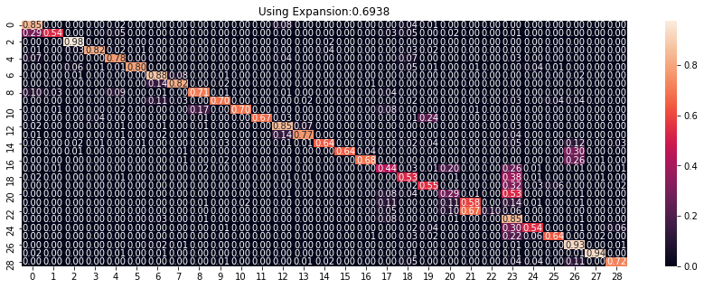

```python
summarize_net(cnn, X_test, y_test, title_text='Using Expansion:')
```

From the results and plot, we get that the accuracy is 0.6938 which is not good enough, so we decide to improve the accuracy in part 2.2

## 2.2 Investigate different CNNs

### 2.2.1. Add two more layers based on cnn created in part 2.1.2

```
_________________________________________________________________
Layer (type)                 Output Shape              Param #
=================================================================
conv2d_3 (Conv2D)            (None, 64, 64, 32)        896
_________________________________________________________________
conv2d_4 (Conv2D)            (None, 64, 64, 64)        18496
_________________________________________________________________
max_pooling2d_2 (MaxPooling2 (None, 32, 32, 64)        0
_________________________________________________________________
conv2d_5 (Conv2D)            (None, 32, 32, 32)        18464
_________________________________________________________________
max_pooling2d_3 (MaxPooling2 (None, 16, 16, 32)        0
_________________________________________________________________
conv2d_6 (Conv2D)            (None, 16, 16, 64)        18496
_________________________________________________________________
dropout_3 (Dropout)          (None, 16, 16, 64)        0
_________________________________________________________________
flatten_2 (Flatten)          (None, 16384)             0
_________________________________________________________________
dense_3 (Dense)              (None, 128)               2097280
_________________________________________________________________
dropout_4 (Dropout)          (None, 128)               0
_________________________________________________________________
dense_4 (Dense)              (None, 29)                3741
=================================================================
Total params: 2,157,373
Trainable params: 2,157,373
Non-trainable params: 0
_________________________________________________________________
None
CPU times: user 6min 42s, sys: 32.6 s, total: 7min 15s
Wall time: 5min 31s
```

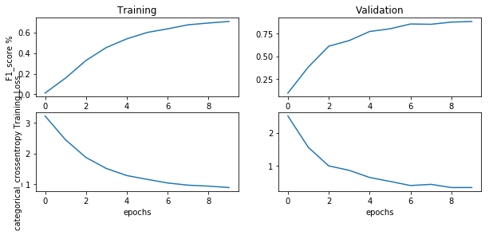

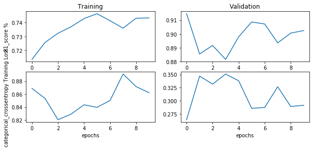

```python
%%time


cnn2 = Sequential()

# let's start with an AlexNet style convolutional phase
cnn2.add(Conv2D(filters=32,
                input_shape = (img_wh,img_wh,3),
                kernel_size=(3,3),
                padding='same',
                activation='relu', data_format="channels_last")) # more compact syntax

# no max pool before next conv layer!!
cnn2.add(Conv2D(filters=64,
                kernel_size=(3,3),
                padding='same',
                activation='relu')) # more compact syntax
cnn2.add(MaxPooling2D(pool_size=(2, 2), data_format="channels_last"))

cnn2.add(Conv2D(filters=32,
                kernel_size=(3,3),
                padding='same',
                activation='relu')) # more compact syntax
cnn2.add(MaxPooling2D(pool_size=(2, 2), data_format="channels_last"))

cnn2.add(Conv2D(filters=64,
                input_shape = (img_wh,img_wh,3),
                kernel_size=(3,3),
                padding='same',
                activation='relu', data_format="channels_last")) # more compact syntax


# add one layer on flattened output
cnn2.add(Dropout(0.25)) # add some dropout for regularization after conv layers
cnn2.add(Flatten())
cnn2.add(Dense(128, activation='relu'))
cnn2.add(Dropout(0.5)) # add some dropout for regularization, again!
cnn2.add(Dense(NUM_CLASSES, activation='softmax'))

cnn2.compile(loss='categorical_crossentropy',
              optimizer='rmsprop',
              metrics=[f1score])
print(cnn2.summary())
cv = StratifiedShuffleSplit(n_splits=2)

for train_index, test_index in cv.split(X,y):
    X_train, X_test = X[train_index], X[test_index]
    y_train, y_test = y[train_index], y[test_index]
    y_train_ohe =  keras.utils.to_categorical(y_train, NUM_CLASSES)
    y_test_ohe =  keras.utils.to_categorical(y_test, NUM_CLASSES)

    history2 = cnn2.fit_generator(datagen.flow(X_train, y_train_ohe, batch_size=32),
                       steps_per_epoch=int(len(X_train)/32), # how many generators to go through per epoch
                       epochs=10, verbose=1,
                       validation_data=(X_test,y_test_ohe))

    plt.figure(figsize=(10,4))
    plt.subplot(2,2,1)
    plt.plot(history2.history['f1score'])

    plt.ylabel('F1_score %')
    plt.title('Training')
    plt.subplot(2,2,2)
    plt.plot(history2.history['val_f1score'])
    plt.title('Validation')

    plt.subplot(2,2,3)
    plt.plot(history2.history['loss'])
    plt.ylabel('categorical_crossentropy Training Loss')
    plt.xlabel('epochs')

    plt.subplot(2,2,4)
    plt.plot(history2.history['val_loss'])
    plt.xlabel('epochs')
```

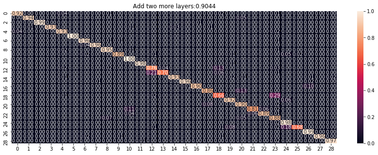

```python
summarize_net(cnn2, X_test, y_test, title_text='Add two more layers:')
```

### Investigate changing some parameters of cnn2

### Increase kernel size based on cnn2

```
_________________________________________________________________
Layer (type)                 Output Shape              Param #
=================================================================
conv2d_7 (Conv2D)            (None, 64, 64, 32)        2432
_________________________________________________________________
conv2d_8 (Conv2D)            (None, 64, 64, 64)        51264
_________________________________________________________________
max_pooling2d_4 (MaxPooling2 (None, 32, 32, 64)        0
_________________________________________________________________
conv2d_9 (Conv2D)            (None, 32, 32, 32)        51232
_________________________________________________________________
max_pooling2d_5 (MaxPooling2 (None, 16, 16, 32)        0
_________________________________________________________________
conv2d_10 (Conv2D)           (None, 16, 16, 64)        51264
_________________________________________________________________
dropout_5 (Dropout)          (None, 16, 16, 64)        0
_________________________________________________________________
flatten_3 (Flatten)          (None, 16384)             0
_________________________________________________________________
dense_5 (Dense)              (None, 128)               2097280
_________________________________________________________________
dropout_6 (Dropout)          (None, 128)               0
_________________________________________________________________
dense_6 (Dense)              (None, 29)                3741
=================================================================
Total params: 2,257,213
Trainable params: 2,257,213
Non-trainable params: 0
_________________________________________________________________
None
CPU times: user 7min 3s, sys: 48 s, total: 7min 51s
Wall time: 5min 41s
```

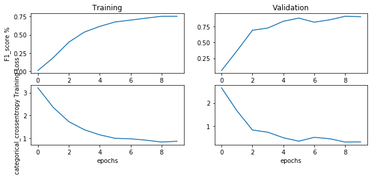

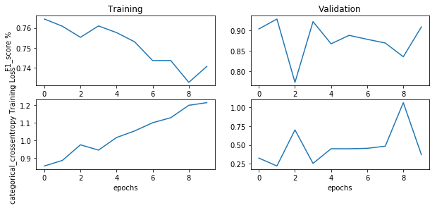

```python
%%time


cnn3 = Sequential()


cnn3.add(Conv2D(filters=32,
                input_shape = (img_wh,img_wh,3),
                kernel_size=(5,5),
                padding='same',
                activation='relu', data_format="channels_last")) # more compact syntax

# no max pool before next conv layer!!
cnn3.add(Conv2D(filters=64,
                kernel_size=(5,5),
                padding='same',
                activation='relu')) # more compact syntax
cnn3.add(MaxPooling2D(pool_size=(2, 2), data_format="channels_last"))

cnn3.add(Conv2D(filters=32,
                kernel_size=(5,5),
                padding='same',
                activation='relu')) # more compact syntax
cnn3.add(MaxPooling2D(pool_size=(2, 2), data_format="channels_last"))

cnn3.add(Conv2D(filters=64,
                input_shape = (img_wh,img_wh,3),
                kernel_size=(5,5),
                padding='same',
                activation='relu', data_format="channels_last")) # more compact syntax


# add one layer on flattened output
cnn3.add(Dropout(0.25)) # add some dropout for regularization after conv layers
cnn3.add(Flatten())
cnn3.add(Dense(128, activation='relu'))
cnn3.add(Dropout(0.5)) # add some dropout for regularization, again!
cnn3.add(Dense(NUM_CLASSES, activation='softmax'))

cnn3.compile(loss='categorical_crossentropy',
              optimizer='rmsprop',
              metrics=[f1score])
print(cnn3.summary())
cv = StratifiedShuffleSplit(n_splits=2)

for train_index, test_index in cv.split(X,y):
    X_train, X_test = X[train_index], X[test_index]
    y_train, y_test = y[train_index], y[test_index]
    y_train_ohe =  keras.utils.to_categorical(y_train, NUM_CLASSES)
    y_test_ohe =  keras.utils.to_categorical(y_test, NUM_CLASSES)

    history3 = cnn3.fit_generator(datagen.flow(X_train, y_train_ohe, batch_size=32),
                       steps_per_epoch=int(len(X_train)/32), # how many generators to go through per epoch
                       epochs=10, verbose=1,
                       validation_data=(X_test,y_test_ohe))

    plt.figure(figsize=(10,4))
    plt.subplot(2,2,1)
    plt.plot(history3.history['f1score'])

    plt.ylabel('F1_score %')
    plt.title('Training')
    plt.subplot(2,2,2)
    plt.plot(history3.history['val_f1score'])
    plt.title('Validation')

    plt.subplot(2,2,3)
    plt.plot(history3.history['loss'])
    plt.ylabel('categorical_crossentropy Training Loss')
    plt.xlabel('epochs')

    plt.subplot(2,2,4)
    plt.plot(history3.history['val_loss'])
    plt.xlabel('epochs')
```

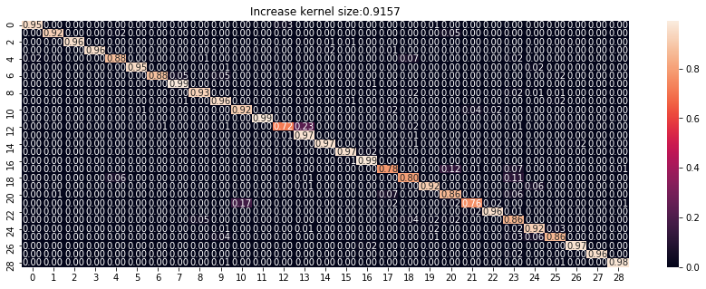

```python
summarize_net(cnn3, X_test, y_test, title_text='Increase kernel size:')
```

We think the kernel size will influence the CNN performance, so we decide to increase the size (3,3) to (5,5). From the result and plot, we can see the accuracy has improved from 0.9044 to 0.9157. It means increase kernel size is useful for improving accuracy.

Then we creat another CNN with adding Resnet Style Blocks

### 2.2.2 ResNet

```
__________________________________________________________________________________________________
Layer (type)                    Output Shape         Param #     Connected to
==================================================================================================
input_1 (InputLayer)            (None, 64, 64, 3)    0
__________________________________________________________________________________________________
conv2d_11 (Conv2D)              (None, 64, 64, 32)   896         input_1[0][0]
__________________________________________________________________________________________________
max_pooling2d_6 (MaxPooling2D)  (None, 32, 32, 32)   0           conv2d_11[0][0]
__________________________________________________________________________________________________
conv2d_12 (Conv2D)              (None, 32, 32, 32)   9248        max_pooling2d_6[0][0]
__________________________________________________________________________________________________
max_pooling2d_7 (MaxPooling2D)  (None, 16, 16, 32)   0           conv2d_12[0][0]
__________________________________________________________________________________________________
conv2d_13 (Conv2D)              (None, 16, 16, 64)   18496       max_pooling2d_7[0][0]
__________________________________________________________________________________________________
conv2d_14 (Conv2D)              (None, 16, 16, 64)   36928       conv2d_13[0][0]
__________________________________________________________________________________________________
conv2d_15 (Conv2D)              (None, 16, 16, 32)   2080        conv2d_14[0][0]
__________________________________________________________________________________________________
add_1 (Add)                     (None, 16, 16, 32)   0           conv2d_15[0][0]
                                                                 max_pooling2d_7[0][0]
__________________________________________________________________________________________________
activation_1 (Activation)       (None, 16, 16, 32)   0           add_1[0][0]
__________________________________________________________________________________________________
max_pooling2d_8 (MaxPooling2D)  (None, 8, 8, 32)     0           activation_1[0][0]
__________________________________________________________________________________________________
flatten_4 (Flatten)             (None, 2048)         0           max_pooling2d_8[0][0]
__________________________________________________________________________________________________
dropout_7 (Dropout)             (None, 2048)         0           flatten_4[0][0]
__________________________________________________________________________________________________
dense_7 (Dense)                 (None, 256)          524544      dropout_7[0][0]
__________________________________________________________________________________________________
activation_2 (Activation)       (None, 256)          0           dense_7[0][0]
__________________________________________________________________________________________________
dropout_8 (Dropout)             (None, 256)          0           activation_2[0][0]
__________________________________________________________________________________________________
dense_8 (Dense)                 (None, 29)           7453        dropout_8[0][0]
__________________________________________________________________________________________________
activation_3 (Activation)       (None, 29)           0           dense_8[0][0]
==================================================================================================
Total params: 599,645
Trainable params: 599,645
Non-trainable params: 0
__________________________________________________________________________________________________
Train on 15660 samples, validate on 1740 samples
Train on 15660 samples, validate on 1740 samples
CPU times: user 1min 17s, sys: 15.5 s, total: 1min 32s
Wall time: 1min 11s
```

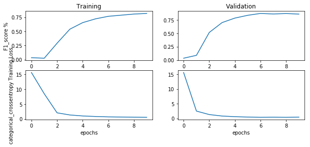

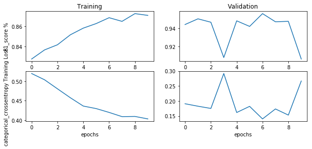

```python
%%time

# now lets use the LeNet architecture with batch norm
# We will also use ReLU where approriate and drop out
from keras.layers.normalization import BatchNormalization
from keras.layers import Add
from keras.layers import average, concatenate
from keras.models import Input, Model

input_holder = Input(shape=(img_wh, img_wh, 3))
l2_lambda = 0.0001

# start with a conv layer
x = Conv2D(filters=32,
               input_shape = (img_wh,img_wh,3),
               kernel_size=(3,3),
               kernel_initializer='he_uniform',
               kernel_regularizer=l2(l2_lambda),
               padding='same',
               activation='relu',
               data_format="channels_last")(input_holder)

x = MaxPooling2D(pool_size=(2, 2), data_format="channels_last")(x)

x = Conv2D(filters=32,
               kernel_size=(3,3),
               kernel_initializer='he_uniform',
               kernel_regularizer=l2(l2_lambda),
               padding='same',
               activation='relu',
               data_format="channels_last")(x)

x_split = MaxPooling2D(pool_size=(2, 2), data_format="channels_last")(x)

x = Conv2D(filters=64,
               kernel_size=(3,3),
               kernel_initializer='he_uniform',
               kernel_regularizer=l2(l2_lambda),
               padding='same',
               activation='relu',
               data_format="channels_last")(x_split)

x = Conv2D(filters=64,
               kernel_size=(3,3),
               kernel_initializer='he_uniform',
               kernel_regularizer=l2(l2_lambda),
               padding='same',
               activation='relu',
               data_format="channels_last")(x)

x = Conv2D(filters=32,
               kernel_size=(1,1),
               kernel_initializer='he_uniform',
               kernel_regularizer=l2(l2_lambda),
               padding='same',
               activation='relu',
               data_format="channels_last")(x)

# now add back in the split layer, x_split (residual added in)
x = Add()([x, x_split])
x = Activation("relu")(x)

x = MaxPooling2D(pool_size=(2, 2), data_format="channels_last")(x)

x = Flatten()(x)
x = Dropout(0.25)(x)
x = Dense(256)(x)
x = Activation("relu")(x)
x = Dropout(0.5)(x)
x = Dense(NUM_CLASSES)(x)
x = Activation('softmax')(x)

resnet = Model(inputs=input_holder,outputs=x)

resnet.summary()

resnet.compile(loss='categorical_crossentropy', # 'categorical_crossentropy' 'mean_squared_error'
                optimizer='rmsprop', # 'adadelta' 'rmsprop'
                metrics=[f1score])

# the flow method yields batches of images indefinitely, with the given transofmrations
# resnet.fit_generator(datagen.flow(X_train, y_train_ohe, batch_size=128),
#                       steps_per_epoch=int(len(X_train)/128), # how many generators to go through per epoch
#                       epochs=50, verbose=1,
#                       validation_data=(X_test,y_test_ohe),
#                       callbacks=[EarlyStopping(monitor='val_loss', patience=4)]
#                      )
for train_index, test_index in cv.split(X,y):
    X_train, X_test = X[train_index], X[test_index]
    y_train, y_test = y[train_index], y[test_index]
    y_train_ohe =  keras.utils.to_categorical(y_train, NUM_CLASSES)
    y_test_ohe =  keras.utils.to_categorical(y_test, NUM_CLASSES)

    history = resnet.fit(X_train, y_train_ohe, batch_size=32,
                      epochs=10, verbose=1,
                      validation_data=(X_test,y_test_ohe),
                      callbacks=[EarlyStopping(monitor='val_loss', patience=4)]
                     )

    plt.figure(figsize=(10,4))
    plt.subplot(2,2,1)
    plt.plot(history.history['f1score'])

    plt.ylabel('F1_score %')
    plt.title('Training')
    plt.subplot(2,2,2)
    plt.plot(history.history['val_f1score'])
    plt.title('Validation')

    plt.subplot(2,2,3)
    plt.plot(history.history['loss'])
    plt.ylabel('categorical_crossentropy Training Loss')
    plt.xlabel('epochs')

    plt.subplot(2,2,4)
    plt.plot(history.history['val_loss'])
    plt.xlabel('epochs')
```

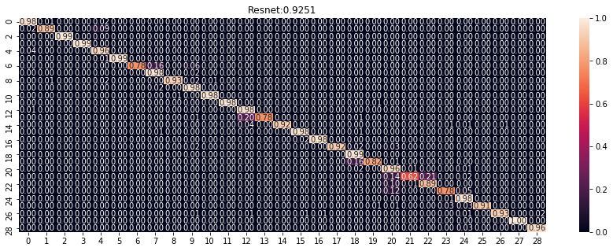

```python
summarize_net(resnet, X_test, y_test, title_text='Resnet:')
```

The result for Resnet is good, then we would like to changing some parameters of Resnet

### Investigate changing some parameters of Resnet

### Change the filter

```
__________________________________________________________________________________________________
Layer (type)                    Output Shape         Param #     Connected to
==================================================================================================
input_3 (InputLayer)            (None, 64, 64, 3)    0
__________________________________________________________________________________________________
conv2d_21 (Conv2D)              (None, 64, 64, 64)   1792        input_3[0][0]
__________________________________________________________________________________________________
max_pooling2d_12 (MaxPooling2D) (None, 32, 32, 64)   0           conv2d_21[0][0]
__________________________________________________________________________________________________
conv2d_22 (Conv2D)              (None, 32, 32, 32)   18464       max_pooling2d_12[0][0]
__________________________________________________________________________________________________
max_pooling2d_13 (MaxPooling2D) (None, 16, 16, 32)   0           conv2d_22[0][0]
__________________________________________________________________________________________________
conv2d_23 (Conv2D)              (None, 16, 16, 32)   9248        max_pooling2d_13[0][0]
__________________________________________________________________________________________________
conv2d_24 (Conv2D)              (None, 16, 16, 64)   18496       conv2d_23[0][0]
__________________________________________________________________________________________________
conv2d_25 (Conv2D)              (None, 16, 16, 32)   2080        conv2d_24[0][0]
__________________________________________________________________________________________________
add_3 (Add)                     (None, 16, 16, 32)   0           conv2d_25[0][0]
                                                                 max_pooling2d_13[0][0]
__________________________________________________________________________________________________
activation_7 (Activation)       (None, 16, 16, 32)   0           add_3[0][0]
__________________________________________________________________________________________________
max_pooling2d_14 (MaxPooling2D) (None, 8, 8, 32)     0           activation_7[0][0]
__________________________________________________________________________________________________
flatten_6 (Flatten)             (None, 2048)         0           max_pooling2d_14[0][0]
__________________________________________________________________________________________________
dropout_11 (Dropout)            (None, 2048)         0           flatten_6[0][0]
__________________________________________________________________________________________________
dense_11 (Dense)                (None, 256)          524544      dropout_11[0][0]
__________________________________________________________________________________________________
activation_8 (Activation)       (None, 256)          0           dense_11[0][0]
__________________________________________________________________________________________________
dropout_12 (Dropout)            (None, 256)          0           activation_8[0][0]
__________________________________________________________________________________________________
dense_12 (Dense)                (None, 29)           7453        dropout_12[0][0]
__________________________________________________________________________________________________
activation_9 (Activation)       (None, 29)           0           dense_12[0][0]
==================================================================================================
Total params: 582,077
Trainable params: 582,077
Non-trainable params: 0
__________________________________________________________________________________________________
Train on 15660 samples, validate on 1740 samples
Train on 15660 samples, validate on 1740 samples
CPU times: user 1min 7s, sys: 14.5 s, total: 1min 22s
Wall time: 1min 6s
```

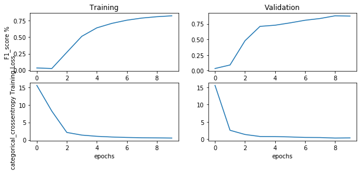

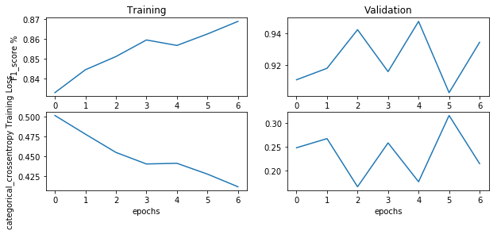

```python
%%time

# now lets use the LeNet architecture with batch norm
# We will also use ReLU where approriate and drop out
from keras.layers.normalization import BatchNormalization
from keras.layers import Add
from keras.layers import average, concatenate
from keras.models import Input, Model

input_holder = Input(shape=(img_wh, img_wh, 3))

# start with a conv layer
x = Conv2D(filters=64,
               input_shape = (img_wh,img_wh,3),
               kernel_size=(3,3),
               kernel_initializer='he_uniform',
               kernel_regularizer=l2(l2_lambda),
               padding='same',
               activation='relu',
               data_format="channels_last")(input_holder)

x = MaxPooling2D(pool_size=(2, 2), data_format="channels_last")(x)

x = Conv2D(filters=32,
               kernel_size=(3,3),
               kernel_initializer='he_uniform',
               kernel_regularizer=l2(l2_lambda),
               padding='same',
               activation='relu',
               data_format="channels_last")(x)

x_split = MaxPooling2D(pool_size=(2, 2), data_format="channels_last")(x)

x = Conv2D(filters=32,
               kernel_size=(3,3),
               kernel_initializer='he_uniform',
               kernel_regularizer=l2(l2_lambda),
               padding='same',
               activation='relu',
               data_format="channels_last")(x_split)

x = Conv2D(filters=64,
               kernel_size=(3,3),
               kernel_initializer='he_uniform',
               kernel_regularizer=l2(l2_lambda),
               padding='same',
               activation='relu',
               data_format="channels_last")(x)

x = Conv2D(filters=32,
               kernel_size=(1,1),
               kernel_initializer='he_uniform',
               kernel_regularizer=l2(l2_lambda),
               padding='same',
               activation='relu',
               data_format="channels_last")(x)

# now add back in the split layer, x_split (residual added in)
x = Add()([x, x_split])
x = Activation("relu")(x)

x = MaxPooling2D(pool_size=(2, 2), data_format="channels_last")(x)

x = Flatten()(x)
x = Dropout(0.25)(x)
x = Dense(256)(x)
x = Activation("relu")(x)
x = Dropout(0.5)(x)
x = Dense(NUM_CLASSES)(x)
x = Activation('softmax')(x)

resnet2 = Model(inputs=input_holder,outputs=x)

resnet2.summary()

resnet2.compile(loss='categorical_crossentropy', # 'categorical_crossentropy' 'mean_squared_error'
                optimizer='rmsprop', # 'adadelta' 'rmsprop'
                metrics=[f1score])

# the flow method yields batches of images indefinitely, with the given transofmrations
# resnet.fit_generator(datagen.flow(X_train, y_train_ohe, batch_size=128),
#                       steps_per_epoch=int(len(X_train)/128), # how many generators to go through per epoch
#                       epochs=50, verbose=1,
#                       validation_data=(X_test,y_test_ohe),
#                       callbacks=[EarlyStopping(monitor='val_loss', patience=4)]
#                      )
for train_index, test_index in cv.split(X,y):
    X_train, X_test = X[train_index], X[test_index]
    y_train, y_test = y[train_index], y[test_index]
    y_train_ohe =  keras.utils.to_categorical(y_train, NUM_CLASSES)
    y_test_ohe =  keras.utils.to_categorical(y_test, NUM_CLASSES)

    history = resnet2.fit(X_train, y_train_ohe, batch_size=32,
                      epochs=10, verbose=1,
                      validation_data=(X_test,y_test_ohe),
                      callbacks=[EarlyStopping(monitor='val_loss', patience=4)]
                     )

    plt.figure(figsize=(10,4))
    plt.subplot(2,2,1)
    plt.plot(history.history['f1score'])

    plt.ylabel('F1_score %')
    plt.title('Training')
    plt.subplot(2,2,2)
    plt.plot(history.history['val_f1score'])
    plt.title('Validation')

    plt.subplot(2,2,3)
    plt.plot(history.history['loss'])
    plt.ylabel('categorical_crossentropy Training Loss')
    plt.xlabel('epochs')

    plt.subplot(2,2,4)
    plt.plot(history.history['val_loss'])
    plt.xlabel('epochs')
```

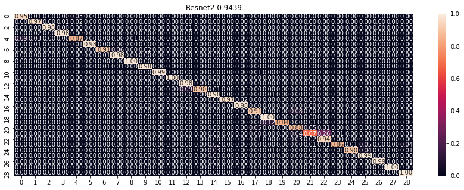

```python
summarize_net(resnet2, X_test, y_test, title_text='Resnet2:')
```

By changing the filters in Resnet, our accuracy becomes better, which increased from 0.92 to 0.94, it means changing filters is helpful to improve Resnet's performance.

Then we creat one more different CNN: Ensemble Nets

### 2.2.3 Ensemble Nets

```
__________________________________________________________________________________________________
Layer (type)                    Output Shape         Param #     Connected to
==================================================================================================
input_4 (InputLayer)            (None, 64, 64, 3)    0
__________________________________________________________________________________________________
conv2d_26 (Conv2D)              (None, 64, 64, 32)   896         input_4[0][0]
__________________________________________________________________________________________________
conv2d_27 (Conv2D)              (None, 64, 64, 32)   9248        conv2d_26[0][0]
__________________________________________________________________________________________________
max_pooling2d_15 (MaxPooling2D) (None, 32, 32, 32)   0           conv2d_27[0][0]
__________________________________________________________________________________________________
conv2d_28 (Conv2D)              (None, 32, 32, 32)   9248        max_pooling2d_15[0][0]
__________________________________________________________________________________________________
conv2d_32 (Conv2D)              (None, 32, 32, 32)   9248        max_pooling2d_15[0][0]
__________________________________________________________________________________________________
conv2d_36 (Conv2D)              (None, 32, 32, 32)   9248        max_pooling2d_15[0][0]
__________________________________________________________________________________________________
conv2d_29 (Conv2D)              (None, 32, 32, 32)   1056        conv2d_28[0][0]
__________________________________________________________________________________________________
conv2d_33 (Conv2D)              (None, 32, 32, 32)   1056        conv2d_32[0][0]
__________________________________________________________________________________________________
conv2d_37 (Conv2D)              (None, 32, 32, 32)   1056        conv2d_36[0][0]
__________________________________________________________________________________________________
max_pooling2d_16 (MaxPooling2D) (None, 16, 16, 32)   0           conv2d_29[0][0]
__________________________________________________________________________________________________
max_pooling2d_18 (MaxPooling2D) (None, 16, 16, 32)   0           conv2d_33[0][0]
__________________________________________________________________________________________________
max_pooling2d_20 (MaxPooling2D) (None, 16, 16, 32)   0           conv2d_37[0][0]
__________________________________________________________________________________________________
conv2d_30 (Conv2D)              (None, 16, 16, 64)   18496       max_pooling2d_16[0][0]
__________________________________________________________________________________________________
conv2d_34 (Conv2D)              (None, 16, 16, 64)   18496       max_pooling2d_18[0][0]
__________________________________________________________________________________________________
conv2d_38 (Conv2D)              (None, 16, 16, 64)   18496       max_pooling2d_20[0][0]
__________________________________________________________________________________________________
conv2d_31 (Conv2D)              (None, 16, 16, 64)   4160        conv2d_30[0][0]
__________________________________________________________________________________________________
conv2d_35 (Conv2D)              (None, 16, 16, 64)   4160        conv2d_34[0][0]
__________________________________________________________________________________________________
conv2d_39 (Conv2D)              (None, 16, 16, 64)   4160        conv2d_38[0][0]
```

[output cut: 30 more lines]

```
__________________________________________________________________________________________________
concatenate_1 (Concatenate)     (None, 87)           0           dense_14[0][0]
                                                                 dense_16[0][0]
                                                                 dense_18[0][0]
__________________________________________________________________________________________________
dense_19 (Dense)                (None, 29)           2552        concatenate_1[0][0]
==================================================================================================
Total params: 903,855
Trainable params: 903,855
Non-trainable params: 0
__________________________________________________________________________________________________
Train on 15660 samples, validate on 1740 samples
Train on 15660 samples, validate on 1740 samples
CPU times: user 1min 51s, sys: 26.6 s, total: 2min 18s
Wall time: 1min 52s
```

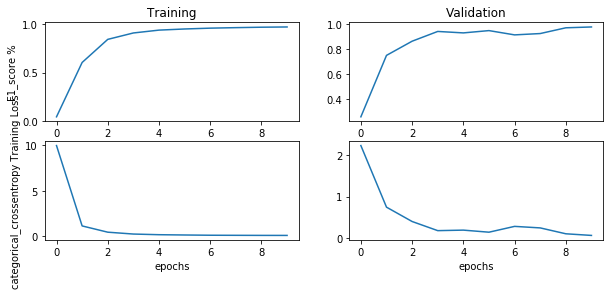

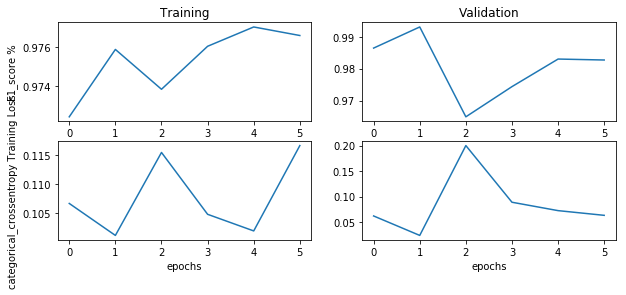

```python
%%time

from keras.layers import average, concatenate
from keras.models import Input, Model


num_ensembles = 3
l2_lambda = 0.000001

input_holder = Input(shape=(img_wh, img_wh, 3))

# start with a conv layer
x = Conv2D(filters=32,
               input_shape = (img_wh,img_wh,1),
               kernel_size=(3,3),
               kernel_initializer='he_uniform',
               kernel_regularizer=l2(l2_lambda),
               padding='same',
               activation='relu', data_format="channels_last")(input_holder)

x = Conv2D(filters=32,
               kernel_size=(3,3),
               kernel_initializer='he_uniform',
               kernel_regularizer=l2(l2_lambda),
               padding='same',
               activation='relu')(x)
input_conv = MaxPooling2D(pool_size=(2, 2), data_format="channels_last")(x)

branches = []
for _ in range(num_ensembles):

    # start using NiN (MLPConv)
    x = Conv2D(filters=32,
                   input_shape = (img_wh,img_wh,1),
                   kernel_size=(3,3),
                   kernel_initializer='he_uniform',
                   kernel_regularizer=l2(l2_lambda),
                   padding='same',
                   activation='linear', data_format="channels_last")(input_conv)

    x = Conv2D(filters=32,kernel_size=(1,1),
                   kernel_initializer='he_uniform',
                   kernel_regularizer=l2(l2_lambda),
                   padding='same',
                   activation='relu', data_format="channels_last")(x)

    x = MaxPooling2D(pool_size=(2, 2), data_format="channels_last")(x)

    x = Conv2D(filters=64,
                   input_shape = (img_wh,img_wh,1),
                   kernel_size=(3,3),
                   kernel_initializer='he_uniform',
                   kernel_regularizer=l2(l2_lambda),
                   padding='same',
                   activation='linear', data_format="channels_last")(x)

    x = Conv2D(filters=64,
                   kernel_size=(1,1),
                   kernel_initializer='he_uniform',
                   kernel_regularizer=l2(l2_lambda),
                   padding='same',
                   activation='linear', data_format="channels_last")(x)

    x = MaxPooling2D(pool_size=(2, 2), data_format="channels_last")(x)

    # add one layer on flattened output
    x = Flatten()(x)
    x = Dropout(0.50)(x) # add some dropout for regularization after conv layers
    x = Dense(64,
              activation='relu',
              kernel_initializer='he_uniform',
              kernel_regularizer=l2(l2_lambda)
            )(x)

    x = Dense(NUM_CLASSES, activation='relu',
              kernel_initializer='he_uniform',
              kernel_regularizer=l2(l2_lambda)
             )(x)

    # now add this branch onto the master list
    branches.append(x)

# that's it, we just need to average the results
x = concatenate(branches)

x = Dense(NUM_CLASSES,
          activation='softmax',
          kernel_initializer='glorot_uniform',
          kernel_regularizer=l2(l2_lambda)
         )(x)

# here is the secret sauce for setting the network using the
#   Functional API:
cnn_ens = Model(inputs=input_holder,outputs=x)

cnn_ens.summary()

cnn_ens.compile(loss='categorical_crossentropy', # 'categorical_crossentropy' 'mean_squared_error'
                optimizer='rmsprop', # 'adadelta' 'rmsprop'
                metrics=[f1score])

for train_index, test_index in cv.split(X,y):
    X_train, X_test = X[train_index], X[test_index]
    y_train, y_test = y[train_index], y[test_index]
    y_train_ohe =  keras.utils.to_categorical(y_train, NUM_CLASSES)
    y_test_ohe =  keras.utils.to_categorical(y_test, NUM_CLASSES)

    history = cnn_ens.fit(X_train, y_train_ohe, batch_size=32,
                      epochs=10, verbose=1,
                      validation_data=(X_test,y_test_ohe),
                      callbacks=[EarlyStopping(monitor='val_loss', patience=4)]
                     )

    plt.figure(figsize=(10,4))
    plt.subplot(2,2,1)
    plt.plot(history.history['f1score'])

    plt.ylabel('F1_score %')
    plt.title('Training')
    plt.subplot(2,2,2)
    plt.plot(history.history['val_f1score'])
    plt.title('Validation')

    plt.subplot(2,2,3)
    plt.plot(history.history['loss'])
    plt.ylabel('categorical_crossentropy Training Loss')
    plt.xlabel('epochs')

    plt.subplot(2,2,4)
    plt.plot(history.history['val_loss'])
    plt.xlabel('epochs')
```

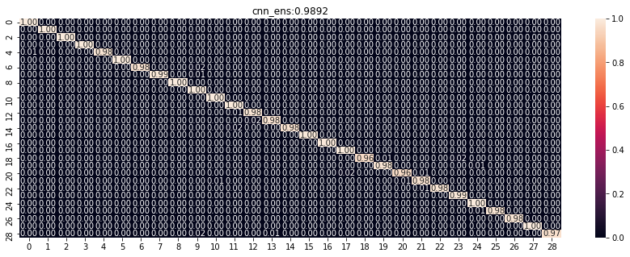

```python
summarize_net(cnn_ens, X_test, y_test, title_text='cnn_ens:')
```

The accuracy for Ensemble Nets is good enough because it can reach 0.98, and we also do the change for parameters to see the influence.

### Investigate changing some parameters of Ensemble Net

### Change the filter

```
__________________________________________________________________________________________________
Layer (type)                    Output Shape         Param #     Connected to
==================================================================================================
input_5 (InputLayer)            (None, 64, 64, 3)    0
__________________________________________________________________________________________________
conv2d_40 (Conv2D)              (None, 64, 64, 32)   896         input_5[0][0]
__________________________________________________________________________________________________
conv2d_41 (Conv2D)              (None, 64, 64, 64)   18496       conv2d_40[0][0]
__________________________________________________________________________________________________
max_pooling2d_22 (MaxPooling2D) (None, 32, 32, 64)   0           conv2d_41[0][0]
__________________________________________________________________________________________________
conv2d_42 (Conv2D)              (None, 32, 32, 64)   36928       max_pooling2d_22[0][0]
__________________________________________________________________________________________________
conv2d_46 (Conv2D)              (None, 32, 32, 64)   36928       max_pooling2d_22[0][0]
__________________________________________________________________________________________________
conv2d_50 (Conv2D)              (None, 32, 32, 64)   36928       max_pooling2d_22[0][0]
__________________________________________________________________________________________________
conv2d_43 (Conv2D)              (None, 32, 32, 32)   2080        conv2d_42[0][0]
__________________________________________________________________________________________________
conv2d_47 (Conv2D)              (None, 32, 32, 32)   2080        conv2d_46[0][0]
__________________________________________________________________________________________________
conv2d_51 (Conv2D)              (None, 32, 32, 32)   2080        conv2d_50[0][0]
__________________________________________________________________________________________________
max_pooling2d_23 (MaxPooling2D) (None, 16, 16, 32)   0           conv2d_43[0][0]
__________________________________________________________________________________________________
max_pooling2d_25 (MaxPooling2D) (None, 16, 16, 32)   0           conv2d_47[0][0]
__________________________________________________________________________________________________
max_pooling2d_27 (MaxPooling2D) (None, 16, 16, 32)   0           conv2d_51[0][0]
__________________________________________________________________________________________________
conv2d_44 (Conv2D)              (None, 16, 16, 32)   9248        max_pooling2d_23[0][0]
__________________________________________________________________________________________________
conv2d_48 (Conv2D)              (None, 16, 16, 32)   9248        max_pooling2d_25[0][0]
__________________________________________________________________________________________________
conv2d_52 (Conv2D)              (None, 16, 16, 32)   9248        max_pooling2d_27[0][0]
__________________________________________________________________________________________________
conv2d_45 (Conv2D)              (None, 16, 16, 64)   2112        conv2d_44[0][0]
__________________________________________________________________________________________________
conv2d_49 (Conv2D)              (None, 16, 16, 64)   2112        conv2d_48[0][0]
__________________________________________________________________________________________________
conv2d_53 (Conv2D)              (None, 16, 16, 64)   2112        conv2d_52[0][0]
```

[output cut: 30 more lines]

```
__________________________________________________________________________________________________
concatenate_2 (Concatenate)     (None, 87)           0           dense_21[0][0]
                                                                 dense_23[0][0]
                                                                 dense_25[0][0]
__________________________________________________________________________________________________
dense_26 (Dense)                (None, 29)           2552        concatenate_2[0][0]
==================================================================================================
Total params: 965,327
Trainable params: 965,327
Non-trainable params: 0
__________________________________________________________________________________________________
Train on 15660 samples, validate on 1740 samples
Train on 15660 samples, validate on 1740 samples
CPU times: user 2min 7s, sys: 43.7 s, total: 2min 51s
Wall time: 2min 28s
```

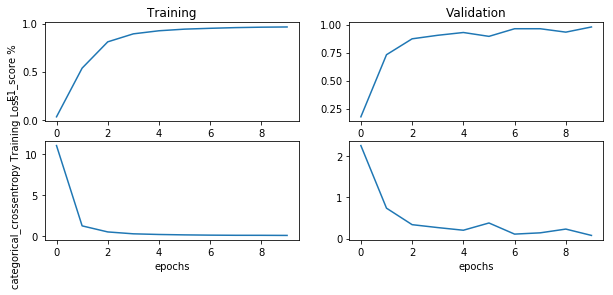

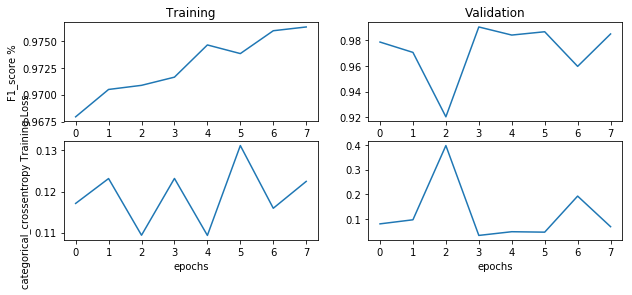

```python
%%time

from keras.layers import average, concatenate
from keras.models import Input, Model


num_ensembles = 3
l2_lambda = 0.000001

input_holder = Input(shape=(img_wh, img_wh, 3))

# start with a conv layer
x = Conv2D(filters=32,
               input_shape = (img_wh,img_wh,1),
               kernel_size=(3,3),
               kernel_initializer='he_uniform',
               kernel_regularizer=l2(l2_lambda),
               padding='same',
               activation='relu', data_format="channels_last")(input_holder)

x = Conv2D(filters=64,
               kernel_size=(3,3),
               kernel_initializer='he_uniform',
               kernel_regularizer=l2(l2_lambda),
               padding='same',
               activation='relu')(x)
input_conv = MaxPooling2D(pool_size=(2, 2), data_format="channels_last")(x)

branches = []
for _ in range(num_ensembles):

    # start using NiN (MLPConv)
    x = Conv2D(filters=64,
                   input_shape = (img_wh,img_wh,1),
                   kernel_size=(3,3),
                   kernel_initializer='he_uniform',
                   kernel_regularizer=l2(l2_lambda),
                   padding='same',
                   activation='linear', data_format="channels_last")(input_conv)

    x = Conv2D(filters=32,kernel_size=(1,1),
                   kernel_initializer='he_uniform',
                   kernel_regularizer=l2(l2_lambda),
                   padding='same',
                   activation='relu', data_format="channels_last")(x)

    x = MaxPooling2D(pool_size=(2, 2), data_format="channels_last")(x)

    x = Conv2D(filters=32,
                   input_shape = (img_wh,img_wh,1),
                   kernel_size=(3,3),
                   kernel_initializer='he_uniform',
                   kernel_regularizer=l2(l2_lambda),
                   padding='same',
                   activation='linear', data_format="channels_last")(x)

    x = Conv2D(filters=64,
                   kernel_size=(1,1),
                   kernel_initializer='he_uniform',
                   kernel_regularizer=l2(l2_lambda),
                   padding='same',
                   activation='linear', data_format="channels_last")(x)

    x = MaxPooling2D(pool_size=(2, 2), data_format="channels_last")(x)

    # add one layer on flattened output
    x = Flatten()(x)
    x = Dropout(0.50)(x) # add some dropout for regularization after conv layers
    x = Dense(64,
              activation='relu',
              kernel_initializer='he_uniform',
              kernel_regularizer=l2(l2_lambda)
            )(x)

    x = Dense(NUM_CLASSES, activation='relu',
              kernel_initializer='he_uniform',
              kernel_regularizer=l2(l2_lambda)
             )(x)

    # now add this branch onto the master list
    branches.append(x)

# that's it, we just need to average the results
x = concatenate(branches)

x = Dense(NUM_CLASSES,
          activation='softmax',
          kernel_initializer='glorot_uniform',
          kernel_regularizer=l2(l2_lambda)
         )(x)

# here is the secret sauce for setting the network using the
#   Functional API:
cnn_ens1 = Model(inputs=input_holder,outputs=x)

cnn_ens1.summary()

cnn_ens1.compile(loss='categorical_crossentropy', # 'categorical_crossentropy' 'mean_squared_error'
                optimizer='rmsprop', # 'adadelta' 'rmsprop'
                metrics=[f1score])
cv = StratifiedShuffleSplit(n_splits=2)
for train_index, test_index in cv.split(X,y):
    X_train, X_test = X[train_index], X[test_index]
    y_train, y_test = y[train_index], y[test_index]
    y_train_ohe =  keras.utils.to_categorical(y_train, NUM_CLASSES)
    y_test_ohe =  keras.utils.to_categorical(y_test, NUM_CLASSES)

    history = cnn_ens1.fit(X_train, y_train_ohe, batch_size=32,
                      epochs=10, verbose=1,
                      validation_data=(X_test,y_test_ohe),
                      callbacks=[EarlyStopping(monitor='val_loss', patience=4)]
                     )
    plt.figure(figsize=(10,4))
    plt.subplot(2,2,1)
    plt.plot(history.history['f1score'])

    plt.ylabel('F1_score %')
    plt.title('Training')
    plt.subplot(2,2,2)
    plt.plot(history.history['val_f1score'])
    plt.title('Validation')

    plt.subplot(2,2,3)
    plt.plot(history.history['loss'])
    plt.ylabel('categorical_crossentropy Training Loss')
    plt.xlabel('epochs')

    plt.subplot(2,2,4)
    plt.plot(history.history['val_loss'])
    plt.xlabel('epochs')
```

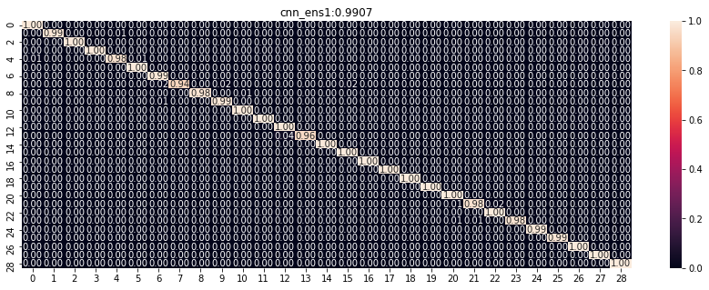

```python
summarize_net(cnn_ens1, X_test, y_test, title_text='cnn_ens1:')
```

### Change l2_lambda

```
__________________________________________________________________________________________________
Layer (type)                    Output Shape         Param #     Connected to
==================================================================================================
input_6 (InputLayer)            (None, 64, 64, 3)    0
__________________________________________________________________________________________________
conv2d_54 (Conv2D)              (None, 64, 64, 32)   896         input_6[0][0]
__________________________________________________________________________________________________
conv2d_55 (Conv2D)              (None, 64, 64, 32)   9248        conv2d_54[0][0]
__________________________________________________________________________________________________
max_pooling2d_29 (MaxPooling2D) (None, 32, 32, 32)   0           conv2d_55[0][0]
__________________________________________________________________________________________________
conv2d_56 (Conv2D)              (None, 32, 32, 32)   9248        max_pooling2d_29[0][0]
__________________________________________________________________________________________________
conv2d_60 (Conv2D)              (None, 32, 32, 32)   9248        max_pooling2d_29[0][0]
__________________________________________________________________________________________________
conv2d_64 (Conv2D)              (None, 32, 32, 32)   9248        max_pooling2d_29[0][0]
__________________________________________________________________________________________________
conv2d_57 (Conv2D)              (None, 32, 32, 32)   1056        conv2d_56[0][0]
__________________________________________________________________________________________________
conv2d_61 (Conv2D)              (None, 32, 32, 32)   1056        conv2d_60[0][0]
__________________________________________________________________________________________________
conv2d_65 (Conv2D)              (None, 32, 32, 32)   1056        conv2d_64[0][0]
__________________________________________________________________________________________________
max_pooling2d_30 (MaxPooling2D) (None, 16, 16, 32)   0           conv2d_57[0][0]
__________________________________________________________________________________________________
max_pooling2d_32 (MaxPooling2D) (None, 16, 16, 32)   0           conv2d_61[0][0]
__________________________________________________________________________________________________
max_pooling2d_34 (MaxPooling2D) (None, 16, 16, 32)   0           conv2d_65[0][0]
__________________________________________________________________________________________________
conv2d_58 (Conv2D)              (None, 16, 16, 64)   18496       max_pooling2d_30[0][0]
__________________________________________________________________________________________________
conv2d_62 (Conv2D)              (None, 16, 16, 64)   18496       max_pooling2d_32[0][0]
__________________________________________________________________________________________________
conv2d_66 (Conv2D)              (None, 16, 16, 64)   18496       max_pooling2d_34[0][0]
__________________________________________________________________________________________________
conv2d_59 (Conv2D)              (None, 16, 16, 64)   4160        conv2d_58[0][0]
__________________________________________________________________________________________________
conv2d_63 (Conv2D)              (None, 16, 16, 64)   4160        conv2d_62[0][0]
__________________________________________________________________________________________________
conv2d_67 (Conv2D)              (None, 16, 16, 64)   4160        conv2d_66[0][0]
```

[output cut: 30 more lines]

```
__________________________________________________________________________________________________
concatenate_3 (Concatenate)     (None, 87)           0           dense_28[0][0]
                                                                 dense_30[0][0]
                                                                 dense_32[0][0]
__________________________________________________________________________________________________
dense_33 (Dense)                (None, 29)           2552        concatenate_3[0][0]
==================================================================================================
Total params: 903,855
Trainable params: 903,855
Non-trainable params: 0
__________________________________________________________________________________________________
Train on 15660 samples, validate on 1740 samples
Train on 15660 samples, validate on 1740 samples
CPU times: user 1min 52s, sys: 27.7 s, total: 2min 19s
Wall time: 1min 53s
```

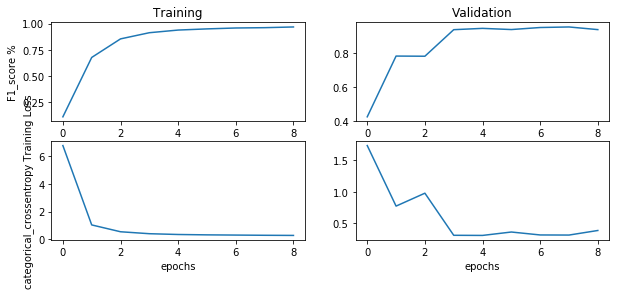

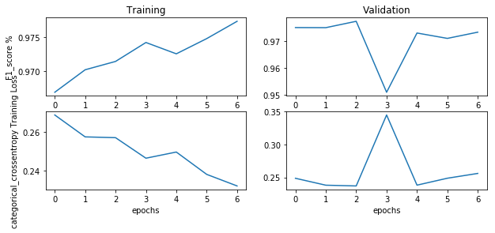

```python
%%time

from keras.layers import average, concatenate
from keras.models import Input, Model


num_ensembles = 3
l2_lambda = 0.0001

input_holder = Input(shape=(img_wh, img_wh, 3))

# start with a conv layer
x = Conv2D(filters=32,
               input_shape = (img_wh,img_wh,1),
               kernel_size=(3,3),
               kernel_initializer='he_uniform',
               kernel_regularizer=l2(l2_lambda),
               padding='same',
               activation='relu', data_format="channels_last")(input_holder)

x = Conv2D(filters=32,
               kernel_size=(3,3),
               kernel_initializer='he_uniform',
               kernel_regularizer=l2(l2_lambda),
               padding='same',
               activation='relu')(x)
input_conv = MaxPooling2D(pool_size=(2, 2), data_format="channels_last")(x)

branches = []
for _ in range(num_ensembles):

    # start using NiN (MLPConv)
    x = Conv2D(filters=32,
                   input_shape = (img_wh,img_wh,1),
                   kernel_size=(3,3),
                   kernel_initializer='he_uniform',
                   kernel_regularizer=l2(l2_lambda),
                   padding='same',
                   activation='linear', data_format="channels_last")(input_conv)

    x = Conv2D(filters=32,kernel_size=(1,1),
                   kernel_initializer='he_uniform',
                   kernel_regularizer=l2(l2_lambda),
                   padding='same',
                   activation='relu', data_format="channels_last")(x)

    x = MaxPooling2D(pool_size=(2, 2), data_format="channels_last")(x)

    x = Conv2D(filters=64,
                   input_shape = (img_wh,img_wh,1),
                   kernel_size=(3,3),
                   kernel_initializer='he_uniform',
                   kernel_regularizer=l2(l2_lambda),
                   padding='same',
                   activation='linear', data_format="channels_last")(x)

    x = Conv2D(filters=64,
                   kernel_size=(1,1),
                   kernel_initializer='he_uniform',
                   kernel_regularizer=l2(l2_lambda),
                   padding='same',
                   activation='linear', data_format="channels_last")(x)

    x = MaxPooling2D(pool_size=(2, 2), data_format="channels_last")(x)

    # add one layer on flattened output
    x = Flatten()(x)
    x = Dropout(0.50)(x) # add some dropout for regularization after conv layers
    x = Dense(64,
              activation='relu',
              kernel_initializer='he_uniform',
              kernel_regularizer=l2(l2_lambda)
            )(x)

    x = Dense(NUM_CLASSES, activation='relu',
              kernel_initializer='he_uniform',
              kernel_regularizer=l2(l2_lambda)
             )(x)

    # now add this branch onto the master list
    branches.append(x)

# that's it, we just need to average the results
x = concatenate(branches)

x = Dense(NUM_CLASSES,
          activation='softmax',
          kernel_initializer='glorot_uniform',
          kernel_regularizer=l2(l2_lambda)
         )(x)

# here is the secret sauce for setting the network using the
#   Functional API:
cnn_ens2 = Model(inputs=input_holder,outputs=x)

cnn_ens2.summary()

cnn_ens2.compile(loss='categorical_crossentropy', # 'categorical_crossentropy' 'mean_squared_error'
                optimizer='rmsprop', # 'adadelta' 'rmsprop'
                metrics=[f1score])

for train_index, test_index in cv.split(X,y):
    X_train, X_test = X[train_index], X[test_index]
    y_train, y_test = y[train_index], y[test_index]
    y_train_ohe =  keras.utils.to_categorical(y_train, NUM_CLASSES)
    y_test_ohe =  keras.utils.to_categorical(y_test, NUM_CLASSES)

    history = cnn_ens2.fit(X_train, y_train_ohe, batch_size=32,
                      epochs=10, verbose=1,
                      validation_data=(X_test,y_test_ohe),
                      callbacks=[EarlyStopping(monitor='val_loss', patience=4)]
                     )
    plt.figure(figsize=(10,4))
    plt.subplot(2,2,1)
    plt.plot(history.history['f1score'])

    plt.ylabel('F1_score %')
    plt.title('Training')
    plt.subplot(2,2,2)
    plt.plot(history.history['val_f1score'])
    plt.title('Validation')

    plt.subplot(2,2,3)
    plt.plot(history.history['loss'])
    plt.ylabel('categorical_crossentropy Training Loss')
    plt.xlabel('epochs')

    plt.subplot(2,2,4)
    plt.plot(history.history['val_loss'])
    plt.xlabel('epochs')
```

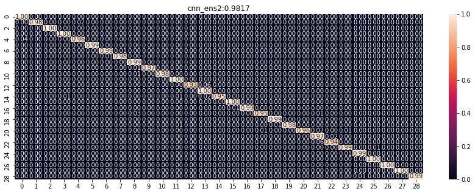

```python
summarize_net(cnn_ens2, X_test, y_test, title_text='cnn_ens2:')
```

After changing the l2_lambda, we can see the result for cnn_ens2 is similar to the first Ensemble Nets. Although it is not increase the result, we can also say the performance is good.

## 2.3 Visualize the final results of the CNNs and compare performance

```python
from sklearn import metrics as mt
from matplotlib import pyplot as plt
import seaborn as sns
%matplotlib inline

def compare_cnn(cnn, cnn2, cnn3, resnet,resnet2,cnn_ens,cnn_ens1,cnn_ens2, X_test, y_test):
    plt.figure(figsize=(15,5))
    plt.subplots_adjust(top=1.5,wspace = 0.2,hspace = 0.5)
    if cnn is not None:
        yhat_cnn = np.argmax(cnn.predict(X_test), axis=1)
        acc_cnn = mt.f1_score(y_test,yhat_cnn,average='macro')
        plt.subplot(4,2,1)
        cm = mt.confusion_matrix(y_test,yhat_cnn)
        cm = cm/np.sum(cm,axis=1)[:,np.newaxis]
        sns.heatmap(cm, annot=True, fmt='.2f')
        plt.title('CNN: '+str(acc_cnn))

    if cnn2 is not None:
        yhat_cnn2 = np.argmax(cnn2.predict(X_test), axis=1)
        acc_cnn2 = mt.f1_score(y_test,yhat_cnn2,average='macro')
        plt.subplot(4,2,2)
        cm = mt.confusion_matrix(y_test,yhat_cnn2)
        cm = cm/np.sum(cm,axis=1)[:,np.newaxis]
        sns.heatmap(cm, annot=True, fmt='.2f')
        plt.title('CNN2: '+str(acc_cnn2))

    if cnn3 is not None:
        yhat_cnn3 = np.argmax(cnn3.predict(X_test), axis=1)
        acc_cnn3 = mt.f1_score(y_test,yhat_cnn3,average='macro')
        plt.subplot(4,2,3)
        cm = mt.confusion_matrix(y_test,yhat_cnn3)
        cm = cm/np.sum(cm,axis=1)[:,np.newaxis]
        sns.heatmap(cm, annot=True, fmt='.2f')
        plt.title('CNN3: '+str(acc_cnn3))

    if resnet is not None:
        yhat_resnet = np.argmax(resnet.predict(X_test), axis=1)
        acc_resnet = mt.f1_score(y_test,yhat_resnet,average='macro')
        plt.subplot(4,2,4)
        cm = mt.confusion_matrix(y_test,yhat_resnet)
        cm = cm/np.sum(cm,axis=1)[:,np.newaxis]
        sns.heatmap(cm, annot=True, fmt='.2f')
        plt.title('Resnet: '+str(acc_resnet))

    if resnet2 is not None:
        yhat_resnet2 = np.argmax(resnet.predict(X_test), axis=1)
        acc_resnet2 = mt.f1_score(y_test,yhat_resnet2,average='macro')
        plt.subplot(4,2,5)
        cm = mt.confusion_matrix(y_test,yhat_resnet2)
        cm = cm/np.sum(cm,axis=1)[:,np.newaxis]
        sns.heatmap(cm, annot=True, fmt='.2f')
        plt.title('Resnet2: '+str(acc_resnet2))

    if cnn_ens is not None:
        yhat_cnn_ens = np.argmax(cnn_ens.predict(X_test), axis=1)
        acc_cnn_ens = mt.f1_score(y_test,yhat_cnn_ens,average='macro')
        plt.subplot(4,2,6)
        cm = mt.confusion_matrix(y_test,yhat_cnn_ens)
        cm = cm/np.sum(cm,axis=1)[:,np.newaxis]
        sns.heatmap(cm, annot=True, fmt='.2f')
        plt.title('cnn_ens: '+str(acc_cnn_ens))

    if cnn_ens1 is not None:
        yhat_cnn_ens1 = np.argmax(cnn_ens1.predict(X_test), axis=1)
        acc_cnn_ens1 = mt.f1_score(y_test,yhat_cnn_ens1,average='macro')
        plt.subplot(4,2,7)
        cm = mt.confusion_matrix(y_test,yhat_cnn_ens1)
        cm = cm/np.sum(cm,axis=1)[:,np.newaxis]
        sns.heatmap(cm, annot=True, fmt='.2f')
        plt.title('cnn_ens1: '+str(acc_cnn_ens1))

    if cnn_ens2 is not None:
        yhat_cnn_ens2 = np.argmax(cnn_ens2.predict(X_test), axis=1)
        acc_cnn_ens2 = mt.f1_score(y_test,yhat_cnn_ens2,average='macro')
        plt.subplot(4,2,8)
        cm = mt.confusion_matrix(y_test,yhat_cnn_ens2)
        cm = cm/np.sum(cm,axis=1)[:,np.newaxis]
        sns.heatmap(cm, annot=True, fmt='.2f')
        plt.title('cnn_ens2: '+str(acc_cnn_ens2))
```

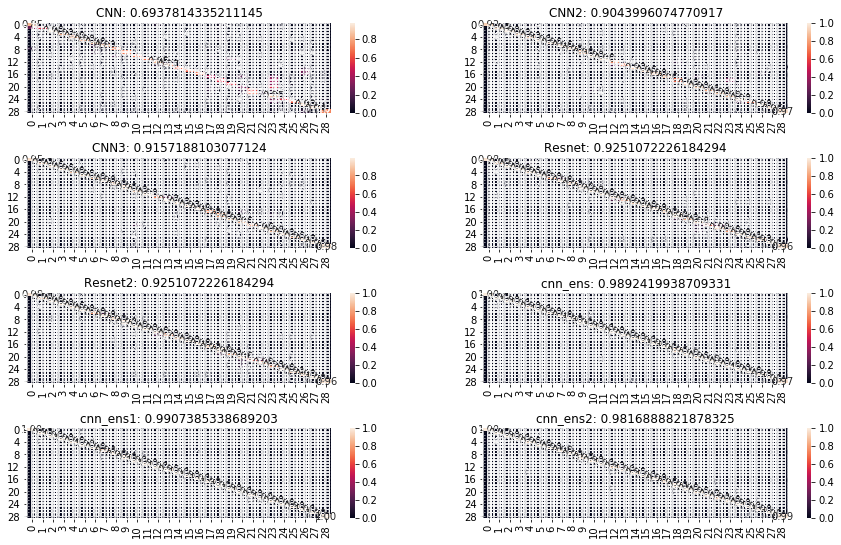

```python
compare_cnn(cnn, cnn2, cnn3, resnet,resnet2,cnn_ens,cnn_ens1,cnn_ens2, X_test, y_test)
```

In order to better compare the result, we decide to visualize and plot all models together. From the result, we can get that the f1_score accuracy is improved by different methods and the model which has best performance is cnn_ens1, the model changed the filters of Ensemble Nets. The result of it is 0.99, and the running time of it is 2min 51s, and it's acceptable for us, as a result, we think the f1_score accuracy is good enough for our dataset. And through these f1_score accuracy showed above, we think increase kernel size and change filters are appropriate for our data set because they can increase the f1_score accuracy to make it better.

## 2.4 Compare the performance of CNN to MLP

### Data Preparation for MLP

```python
y_mlp=[]
label=0
for i, imageLabel in enumerate(images1):
    for image in imageLabel:
        y_mlp.append(label)
    label=label+1
y_mlp=np.array(y_mlp)
```

```python
np_data=np.array([item for sublist in images1 for item in sublist])
from scipy.misc import imresize

for i in range(len(np_data)):
    np_data[i]=imresize(np_data[i],size=(64,64,3),interp='nearest')
```

```python
n_samples = np_data.shape[0]
h = np_data[0].shape[0]
w = np_data[0].shape[1]
np_data.shape
```

```
(17400, 64, 64, 3)
```

```python
num_data=len(np_data)
vec=[]
for i in range(num_data):
    vec.append(np_data[i].reshape(1,-1))
vec[0].shape
```

```
(1, 12288)
```

```python
np_vec=np.array(vec)
#normalize np_vec
x_mlp=np_vec/255-0.5
x_mlp.shape
```

```
(17400, 1, 12288)
```

```python
from tensorflow import set_random_seed
set_random_seed(2)
np.random.seed(0) # using this to help make results reproducible
cv = StratifiedShuffleSplit(n_splits=2)
for train_index, test_index in cv.split(x_mlp,y_mlp):
    X_train_mlp, X_test_mlp = x_mlp[train_index], x_mlp[test_index]
    y_train_mlp, y_test_mlp = y_mlp[train_index], y_mlp[test_index]

#Split X_train again to create validation data
#X_train, X_test, y_train, y_test = cv.split(x,Y)
X_train_mlp.shape


# X_train.shape
```

```
(15660, 1, 12288)
```

```python
sampley_train=X_train_mlp.shape[0]
sampley_test=X_test_mlp.shape[0]

X_train_vector_mlp=X_train_mlp.reshape((sampley_train,-1))
X_test_vector_mlp=X_test_mlp.reshape((sampley_test,-1))
X_train_vector_mlp.shape
```

```
(15660, 12288)
```

```python
n_classes1 = 29
y_train_ohe_mlp = keras.utils.to_categorical(y_train_mlp, n_classes1)
y_test_ohe_mlp = keras.utils.to_categorical(y_test_mlp, n_classes1)
y_train_ohe_mlp.shape
```

```
(15660, 29)
```

```python
y_train_mlp = []
for i in range(len(y_train_ohe_mlp)):
    y_train_mlp.append(np.argmax(y_train_ohe_mlp[i]))

y_train_mlp = np.array(y_train_mlp)
```

```python
y_test_mlp = []
for i in range(len(y_test_ohe_mlp)):
    y_test_mlp.append(np.argmax(y_test_ohe_mlp[i]))

y_test_mlp = np.array(y_test_mlp)
```

### Raw Pixel Input MLP

```python
%%time
from sklearn.model_selection import StratifiedShuffleSplit
#y_train_ohe = keras.utils.to_categorical(y_train, n_classes)
#y_test_ohe = keras.utils.to_categorical(y_test, n_classes)

# make a 3 layer keras MLP
mlp = Sequential()
mlp.add( Dense(input_dim=X_train_vector_mlp.shape[1], units=30, activation='relu') )
mlp.add( Dense(units=15, activation='relu') )
mlp.add( Dense(n_classes1) )
mlp.add( Activation('softmax') )

mlp.compile(loss='mean_squared_error',
              optimizer='rmsprop',
              metrics=[f1score])

mlp.fit(X_train_vector_mlp, y_train_ohe_mlp,
        batch_size=16, epochs=15,
        shuffle=True, verbose=1)

#cv = StratifiedShuffleSplit(n_splits=2)
#for train_index, test_index in cv.split(X_mlp,y_mlp_ohe):
    #X_train, X_test = X_mlp[train_index], X_mlp[test_index]
    #y_train, y_test = y_mlp_ohe[train_index], y_mlp_ohe[test_index]
    #print(X_train,y_train)
    #mlp.fit(X_train, y_train,
        #batch_size=32, epochs=10,
        #shuffle=True, verbose=1)
```

```
CPU times: user 1min 7s, sys: 6.74 s, total: 1min 14s
Wall time: 54.1 s
```

### The ROC of MLP

```python
from scipy import interp

def plot_roc(probas, y_true):
    plt.figure(figsize=(12,5))
    mean_tpr = 0.0
    mean_fpr = np.linspace(0, 1, 100)
    all_tpr = []

    classes = np.unique(y_true)
    perclass_mean_tpr = 0.0
    roc_auc = 0
    for j in classes:
        fpr, tpr, thresholds = mt.roc_curve(y_true, probas[:, j], pos_label=j)
        perclass_mean_tpr += interp(mean_fpr, fpr, tpr)
        perclass_mean_tpr[0] = 0.0
        roc_auc += mt.auc(fpr, tpr)
        plt.plot(fpr,tpr,'--',lw=.5,label='Class ROC Fold, AUC=%0.2f'
                     %(mt.auc(fpr, tpr)) )

    perclass_mean_tpr /= len(classes)
    roc_auc /= len(classes)
    mean_tpr += perclass_mean_tpr

    plt.plot(mean_fpr,perclass_mean_tpr,'-',lw=2,label='Mean Class ROC Fold, AUC=%0.2f'
                     %(roc_auc))
    plt.legend(loc='best')
    plt.xlabel('false positive rate')
    plt.ylabel('true positive rate')
    plt.title('ROC Curve')
```

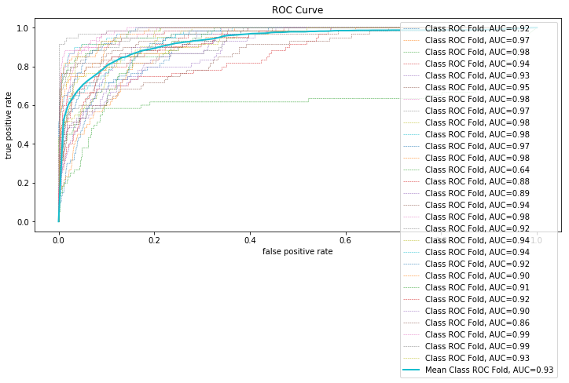

```python
probas = mlp.predict_proba(X_test_vector_mlp)
plot_roc(probas, y_test_mlp)
```

From the ROC plot of MLP above, we can tell that the performance of MLP for our dataset is really good, and the mean class ROC accuracy for MLP is 0.93,that's good. And we want to compare it with the our best performance model, which is the model changed filters for Ensemble Net. We also plot out the ROC curve for filter changed Ensemble Net model.

### Ensemble Net ROC

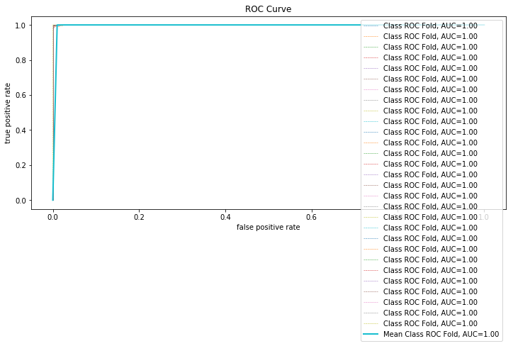

```python
probas = cnn_ens1.predict(X_test)
plot_roc(probas, y_test)
```

From the ROC plot of filter changed Ensemble Nets model above, we can tell that the performance of it is really good, the mean class ROC accuracy is 1.0, that's make sense from the comparasion above. And compare to MLP ROC plot, filter changed Ensemble Nets performance is better for our dataset. And from the running time, MLP runs 1min 14s, and filter changed Ensemble Nets runs 2min 51s, it's obviously that MLP is faster, however, 2min 51s is also acceptable. For us, we still like filter changed Ensemble Nets more since the acceptable running time and high accuracy.

### Keras ROC of CNN and MLP

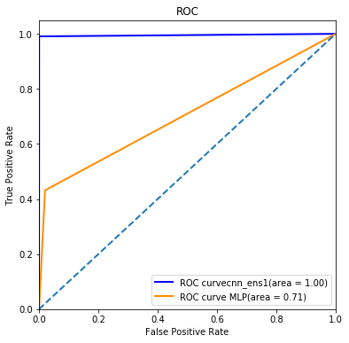

```python
from sklearn.metrics import roc_curve, auc

#yhat_mlp = np.argmax(mlp.predict(X_test_vector), axis=1)
#acc_mlp = mt.accuracy_score(y_test,yhat_mlp)

yhat_cnn_ens1 = np.argmax(cnn_ens1.predict(X_test), axis=1)
yhat_cnn_ens1 = keras.utils.to_categorical(yhat_cnn_ens1, n_classes1)
y_test_cnn_ens1 = keras.utils.to_categorical(y_test, n_classes1)
fpr_cnn_ens1,tpr_cnn_ens1,threshold_cnn_ens1 = roc_curve(y_test_cnn_ens1.ravel(), yhat_cnn_ens1.ravel())
roc_auc_cnn_ens1 = auc(fpr_cnn_ens1,tpr_cnn_ens1)


yhat_mlp = np.argmax(mlp.predict(X_test_vector_mlp), axis=1)
yhat_mlp = keras.utils.to_categorical(yhat_mlp, n_classes1)
y_test_mlp1 = keras.utils.to_categorical(y_test_mlp, n_classes1)
fpr_mlp,tpr_mlp,threshold_mlp = roc_curve(y_test_mlp1.ravel(), yhat_mlp.ravel())
roc_auc_mlp = auc(fpr_mlp,tpr_mlp)

lw = 2
plt.figure(figsize=(6,6))


plt.plot(fpr_cnn_ens1, tpr_cnn_ens1, color='blue',
         lw=lw, label='ROC curvecnn_ens1(area = %0.2f)' % roc_auc_cnn_ens1)
plt.plot(fpr_mlp, tpr_mlp, color='darkorange',
         lw=lw, label='ROC curve MLP(area = %0.2f)' % roc_auc_mlp)

plt.plot([0, 1], [0, 1], lw=lw, linestyle='--')
plt.xlim([0.0, 1.0])
plt.ylim([0.0, 1.05])
plt.xlabel('False Positive Rate')
plt.ylabel('True Positive Rate')
plt.title('ROC')
plt.legend(loc="best")
plt.show()
```

We used another way to compare the ROC of MLP and filter changed Ensemble Nets as the plot above, it's abvious that the filter changed Ensemble Nets' performance is better. The accuracy for MLP in this way is 0.71, it's not good as the above MLP accuracy. We think this is maybe caused by different calculate methods. And it is easy to tell that no matter which method we use to calculate the area under the curve,filter changed Ensemble Nets always better than MLP.

```python
from sklearn import metrics as mt
from matplotlib import pyplot as plt
import seaborn as sns
%matplotlib inline

def compare_mlp_ens1(cnn_ens1, mlp, X_test, y_test, X_test_vector_mlp,y_test_mlp):
    plt.figure(figsize=(15,5))
    if cnn_ens1 is not None:
        yhat_cnn_ens1 = np.argmax(cnn_ens1.predict(X_test), axis=1)
        acc_cnn_ens1 = mt.f1_score(y_test,yhat_cnn_ens1,average='macro')
        plt.subplot(1,2,1)
        cm = mt.confusion_matrix(y_test,yhat_cnn_ens1)
        cm = cm/np.sum(cm,axis=1)[:,np.newaxis]
        sns.heatmap(cm, annot=True, fmt='.2f')
        plt.title('Ensemble: '+str(acc_cnn_ens1))

    if mlp is not None:
        yhat_mlp = np.argmax(mlp.predict(X_test_vector_mlp), axis=1)
        acc_mlp = mt.f1_score(y_test_mlp,yhat_mlp,average='macro')
        plt.subplot(1,2,2)
        cm = mt.confusion_matrix(y_test_mlp,yhat_mlp)
        cm = cm/np.sum(cm,axis=1)[:,np.newaxis]
        sns.heatmap(cm,annot=True, fmt='.2f')
        plt.title('MLP: '+str(acc_mlp))
```

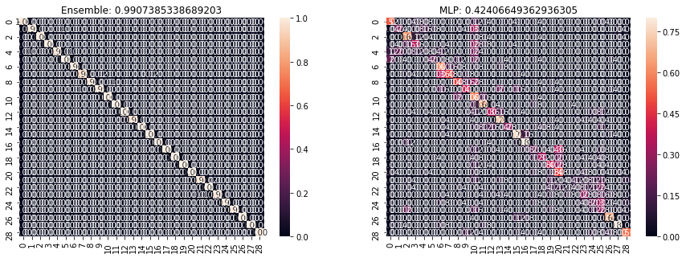

```python
compare_mlp_ens1(cnn_ens1, mlp, X_test, y_test, X_test_vector_mlp,y_test_mlp)
```

We also compared the performance of MLP and filter changed Ensemble Nets by using heatmap, and the accuracy of filter changed Ensemble Nets is 0.99, way better than MLP's 0.424.

# 3. Exceptional work

## Transfer Learning With ResNet

```python
NUM_CLASSES = 29

cv = StratifiedShuffleSplit(n_splits=2)
for train_index, test_index in cv.split(X,y):
    x_train, x_test = X[train_index], X[test_index]
    y_train, y_test = y[train_index], y[test_index]
    y_train_ohe =  keras.utils.to_categorical(y_train, NUM_CLASSES)
    y_test_ohe =  keras.utils.to_categorical(y_test, NUM_CLASSES)
    print(x_train.shape)
    print(y_train.shape)
    print(y_train_ohe.shape)
    print(x_test.shape)
    print(y_test.shape)
    print(y_test_ohe.shape)
```

```
(15660, 64, 64, 3)
(15660,)
(15660, 29)
(1740, 64, 64, 3)
(1740,)
(1740, 29)
(15660, 64, 64, 3)
(15660,)
(15660, 29)
(1740, 64, 64, 3)
(1740,)
(1740, 29)
```

To save time, just use data in the second split.

```python
%%time

from scipy.misc import imresize

x_train_up = [imresize(x, size=(224,224,3), interp='nearest') for x in x_train]
x_train_up = np.stack(x_train_up, axis=0)
print(x_train_up.shape)

x_test_up = [imresize(x, size=(224,224,3), interp='nearest') for x in x_test]
x_test_up = np.stack(x_test_up, axis=0)
print(x_test_up.shape)
```

```
(15660, 224, 224, 3)
```

```
(1740, 224, 224, 3)
CPU times: user 5.38 s, sys: 2.03 s, total: 7.41 s
Wall time: 7.42 s
```

```python
%%time

from keras.applications.resnet50 import ResNet50
from keras.preprocessing import image
from keras.applications.resnet50 import preprocess_input, decode_predictions
res_model = ResNet50(weights='imagenet')
# connect new layers to the output
x = res_model.output

# let's add a fully-connected layer
x = Dense(1024, activation='relu',kernel_initializer='he_uniform')(x)
# and a fully connected layer
predictions = Dense(NUM_CLASSES, activation='softmax', kernel_initializer='glorot_uniform')(x)

model = Model(inputs=res_model.input, outputs=predictions)

# freeze ResNet during training
for layer in res_model.layers:
    layer.trainable = False

model.summary()
```

```
WARNING:tensorflow:From /opt/conda/lib/python3.6/site-packages/tensorflow/python/framework/op_def_library.py:263: colocate_with (from tensorflow.python.framework.ops) is deprecated and will be removed in a future version.
Instructions for updating:
Colocations handled automatically by placer.
__________________________________________________________________________________________________
Layer (type)                    Output Shape         Param #     Connected to
==================================================================================================
input_1 (InputLayer)            (None, 224, 224, 3)  0
__________________________________________________________________________________________________
conv1_pad (ZeroPadding2D)       (None, 230, 230, 3)  0           input_1[0][0]
__________________________________________________________________________________________________
conv1 (Conv2D)                  (None, 112, 112, 64) 9472        conv1_pad[0][0]
__________________________________________________________________________________________________
bn_conv1 (BatchNormalization)   (None, 112, 112, 64) 256         conv1[0][0]
__________________________________________________________________________________________________
activation_1 (Activation)       (None, 112, 112, 64) 0           bn_conv1[0][0]
__________________________________________________________________________________________________
pool1_pad (ZeroPadding2D)       (None, 114, 114, 64) 0           activation_1[0][0]
__________________________________________________________________________________________________
max_pooling2d_1 (MaxPooling2D)  (None, 56, 56, 64)   0           pool1_pad[0][0]
__________________________________________________________________________________________________
res2a_branch2a (Conv2D)         (None, 56, 56, 64)   4160        max_pooling2d_1[0][0]
__________________________________________________________________________________________________
bn2a_branch2a (BatchNormalizati (None, 56, 56, 64)   256         res2a_branch2a[0][0]
__________________________________________________________________________________________________
activation_2 (Activation)       (None, 56, 56, 64)   0           bn2a_branch2a[0][0]
__________________________________________________________________________________________________
res2a_branch2b (Conv2D)         (None, 56, 56, 64)   36928       activation_2[0][0]
__________________________________________________________________________________________________
bn2a_branch2b (BatchNormalizati (None, 56, 56, 64)   256         res2a_branch2b[0][0]
__________________________________________________________________________________________________
activation_3 (Activation)       (None, 56, 56, 64)   0           bn2a_branch2b[0][0]
__________________________________________________________________________________________________
res2a_branch2c (Conv2D)         (None, 56, 56, 256)  16640       activation_3[0][0]
__________________________________________________________________________________________________
res2a_branch1 (Conv2D)          (None, 56, 56, 256)  16640       max_pooling2d_1[0][0]
__________________________________________________________________________________________________
bn2a_branch2c (BatchNormalizati (None, 56, 56, 256)  1024        res2a_branch2c[0][0]
__________________________________________________________________________________________________
bn2a_branch1 (BatchNormalizatio (None, 56, 56, 256)  1024        res2a_branch1[0][0]
__________________________________________________________________________________________________
```

[output cut: 331 more lines]

```
__________________________________________________________________________________________________
avg_pool (GlobalAveragePooling2 (None, 2048)         0           activation_49[0][0]
__________________________________________________________________________________________________
fc1000 (Dense)                  (None, 1000)         2049000     avg_pool[0][0]
__________________________________________________________________________________________________
dense_1 (Dense)                 (None, 1024)         1025024     fc1000[0][0]
__________________________________________________________________________________________________
dense_2 (Dense)                 (None, 29)           29725       dense_1[0][0]
==================================================================================================
Total params: 26,691,461
Trainable params: 1,054,749
Non-trainable params: 25,636,712
__________________________________________________________________________________________________
CPU times: user 11.2 s, sys: 536 ms, total: 11.7 s
Wall time: 12 s
```

```python
%%time

model.compile(optimizer='rmsprop', loss='categorical_crossentropy',metrics=[f1score])

model.fit(x_train_up,y_train_ohe,epochs=10,
          batch_size=32,verbose=1,
          validation_data=(x_test_up, y_test_ohe))
```

```
WARNING:tensorflow:From /opt/conda/lib/python3.6/site-packages/tensorflow/python/ops/math_ops.py:3066: to_int32 (from tensorflow.python.ops.math_ops) is deprecated and will be removed in a future version.
Instructions for updating:
Use tf.cast instead.
Train on 15660 samples, validate on 1740 samples
CPU times: user 59.4 s, sys: 15.3 s, total: 1min 14s
Wall time: 2min 6s
```

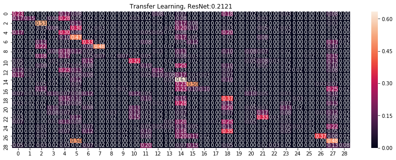

```python
summarize_net(model, x_test_up, y_test, title_text='Transfer Learning, ResNet:')
```

According to the results above, this model looks not fit well for our dataset. The reason could be that there is a big difference between our dataset and the dataset of the ResNet50 using imagenet as weights. Transfer learning performs worse than training from scratch.